# Pstat231HW3

Wentao Yu

2022-10-19

```r
df <- read.csv('/Users/wentaoyu/Documents/UCSB File/Stats/Pstat131/HWs/homework-3/data/titanic.csv') %>%
  mutate(survived = factor(survived,
                           levels = c("Yes", "No")),
         pclass = factor(pclass))
```

## Question 1

```r
set.seed(891) # keep the outcome stable
titanic_split <- initial_split(df, prop = 0.80, strata = survived) # split the data and stratified on survived
titanic_training <- training(titanic_split) # extract the training data
titanic_testing <- testing(titanic_split) # extract the testing data
#titanic_training
# titanic_testing
```

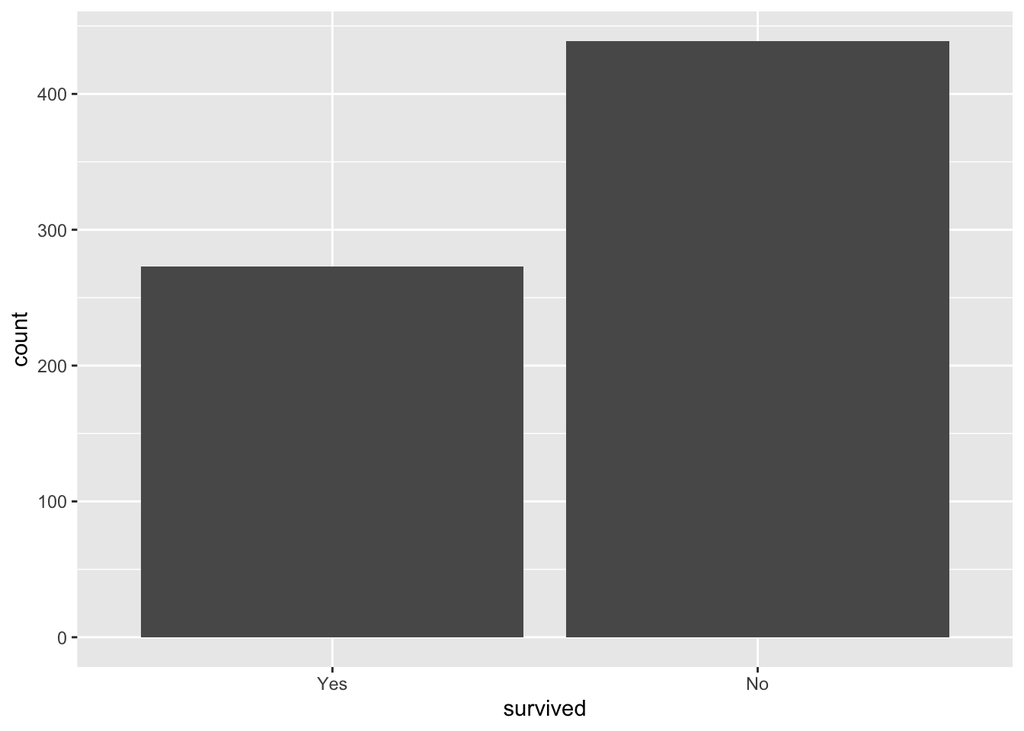

```r
ggplot(titanic_training, aes(survived))+
  geom_bar()
```

From the graph, this looks like a binomial distribution.

## Question 3

```r
cor_titanic <- titanic_training %>%
  select(-c(survived, name, sex, ticket, cabin, embarked)) %>%  # eliminate chr type elements
  correlate()
```

```
## Non-numeric variables removed from input: `pclass`
## Correlation computed with
## • Method: 'pearson'
## • Missing treated using: 'pairwise.complete.obs'
```

```r
cor_titanic
```

```
## # A tibble: 5 × 6
##   term         passenger_id     age  sib_sp    parch    fare
##   <chr>               <dbl>   <dbl>   <dbl>    <dbl>   <dbl>
## 1 passenger_id     NA        0.0235 -0.0333  0.00796  0.0243
## 2 age               0.0235  NA      -0.308  -0.203    0.0882
## 3 sib_sp           -0.0333  -0.308  NA       0.397    0.148
## 4 parch             0.00796 -0.203   0.397  NA        0.216
## 5 fare              0.0243   0.0882  0.148   0.216   NA
```

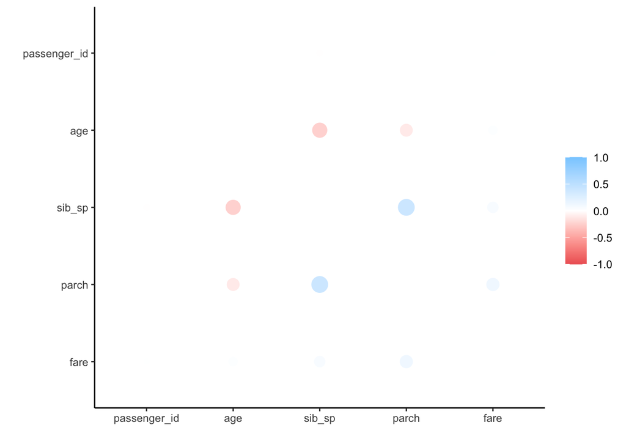

```r
rplot(cor_titanic) # plot the correlation between continuous elements.
```

parch and sib_sp have positive relation, sib_sp and age have negative relation, parch and age have negative relation.

## Question 4

```r
titanic_recipe <- recipe(survived ~ pclass+sex+age+sib_sp+parch+fare, data = titanic_training) %>%
  step_impute_linear(age) %>%
  step_dummy(all_nominal_predictors()) %>%
  step_interact(terms = ~ starts_with('sex'):fare+
                  age:fare)
summary(titanic_recipe)
```

```
## # A tibble: 7 × 4
##   variable type    role      source
##   <chr>    <chr>   <chr>     <chr>
## 1 pclass   nominal predictor original
## 2 sex      nominal predictor original
## 3 age      numeric predictor original
## 4 sib_sp   numeric predictor original
## 5 parch    numeric predictor original
## 6 fare     numeric predictor original
## 7 survived nominal outcome   original
```

## Question 5

```r
log_reg <- logistic_reg() %>%
  set_engine('glm') %>%
  set_mode('classification')
log_wf <- workflow() %>%
  add_model(log_reg) %>%
  add_recipe(titanic_recipe)
log_fit <- fit(log_wf, titanic_training)
```

## Question 6

```r
lda_mode <- discrim_linear() %>%
  set_engine('MASS') %>%
  set_mode('classification')
lda_wf <- workflow() %>%
  add_model(lda_mode) %>%
  add_recipe(titanic_recipe)
lda_fit <- fit(lda_wf, titanic_training)
```

## Question 7

```r
qda_mode <- discrim_quad() %>%
  set_engine('MASS') %>%
  set_mode('classification')
qda_wf <- workflow() %>%
  add_model(qda_mode) %>%
  add_recipe(titanic_recipe)
qda_fit <- fit(qda_wf, titanic_training)
```

## Question 8

```r
nb_mode <- naive_Bayes() %>%
  set_mode("classification") %>%
  set_engine("klaR") %>%
  set_args(usekernel = FALSE)
nb_wf <- workflow() %>%
  add_model(nb_mode) %>%
  add_recipe(titanic_recipe)
nb_fit <- fit(nb_wf, titanic_training)
```

## Question 9

```r
log_acc <- predict(log_fit, new_data = titanic_training, type = 'class') %>%
  bind_cols(titanic_training %>% select(survived)) %>%
  accuracy(truth = survived, estimate = .pred_class)
```

```r
lda_acc <- predict(lda_fit, new_data = titanic_training, type = 'class') %>%
  bind_cols(titanic_training %>% select(survived)) %>%
  accuracy(truth = survived, estimate = .pred_class)
```

```r
qda_acc <- predict(qda_fit, new_data = titanic_training, type = 'class') %>%
  bind_cols(titanic_training %>% select(survived)) %>%
  accuracy(truth = survived, estimate = .pred_class)
```

```r
nb_acc <- predict(nb_fit, new_data = titanic_training, type = 'class') %>%
  bind_cols(titanic_training %>% select(survived)) %>%
  accuracy(truth = survived, estimate = .pred_class)
```

```r
results <- bind_rows(log_acc, lda_acc, qda_acc, nb_acc) %>%
  tibble() %>% mutate(model = c("Logistic Regression", "Linear Discrminant Analysis", "Quadratic Discrminant Analysis", "Naive-Bayes Analysis")) %>%
  select(model, .estimate)
results
```

```
## # A tibble: 4 × 2
##   model                          .estimate
##   <chr>                              <dbl>
## 1 Logistic Regression                0.815
## 2 Linear Discrminant Analysis        0.798
## 3 Quadratic Discrminant Analysis     0.777
## 4 Naive-Bayes Analysis               0.774
```

Logistic Regression has the highest accuracy.

## Question 10

```r
log_fit_test <- fit(log_wf, titanic_testing)
log_test_acc <- predict(log_fit_test, titanic_testing) %>%
  bind_cols(titanic_testing %>% select(survived)) %>%
  accuracy(truth = survived, estimate = .pred_class)
log_test_acc
```

```
## # A tibble: 1 × 3
##   .metric  .estimator .estimate
##   <chr>    <chr>          <dbl>
## 1 accuracy binary         0.832
```

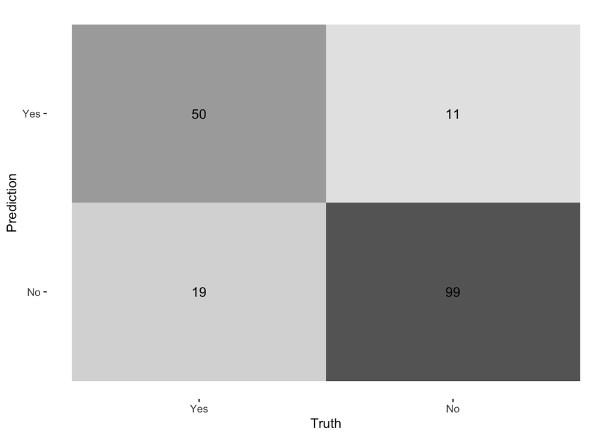

```r
log_result <- augment(log_fit_test, titanic_testing)
log_result %>%
  conf_mat(truth = survived, estimate = .pred_class) %>%
  autoplot(type = "heatmap")
```

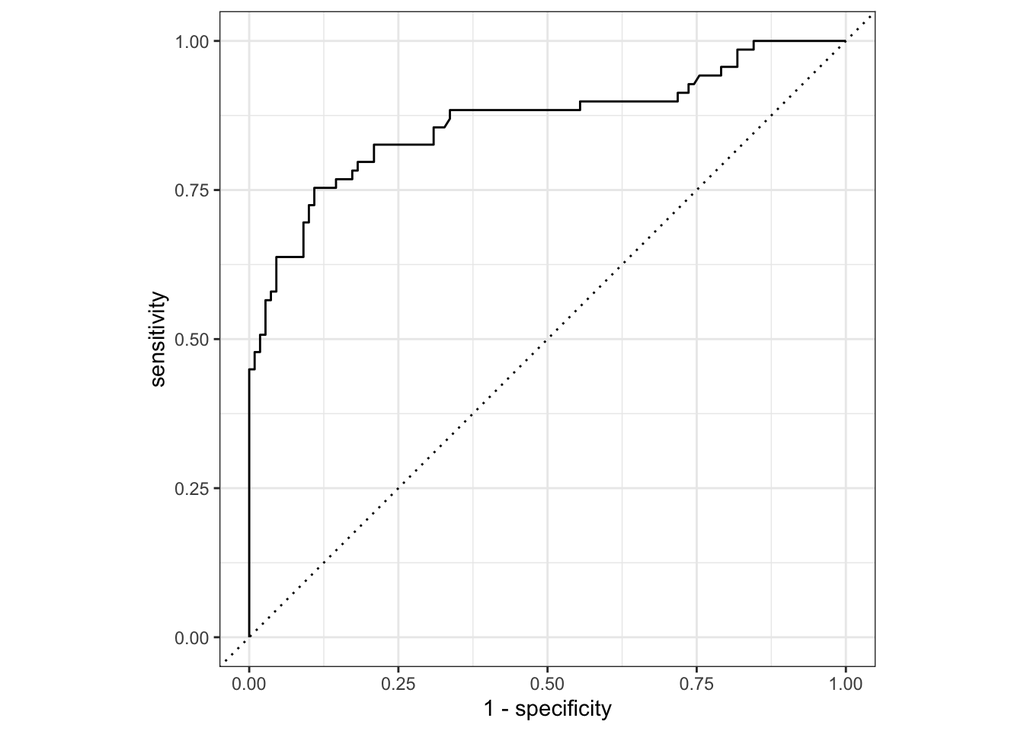

```r
log_result %>%
  roc_curve(survived, .pred_Yes) %>%
  autoplot()
```

```r
log_result %>%
  roc_auc(survived, .pred_Yes) # calculate the area under the roc curve
```

```
## # A tibble: 1 × 3
##   .metric .estimator .estimate
##   <chr>   <chr>          <dbl>
## 1 roc_auc binary         0.864
```

The model performs pretty well as the auc is 0.8637681 which is pretty closed to 1. The accuracy for testing data is more higher than the training data. It shows that the model fitting is pretty good.

## Required For Pstat231

## Question 11

Given that: $p(z) = \frac{e^z}{1+e^z}$
$$\begin{equation}
p(1+e^z) = e^z\\
p+pe^z=e^z\\
(1-p)e^z=p\\
e^z=\frac{p}{1-p}\\
z = ln(\frac{p}{1-p})\\
z(p)=ln(\frac{p}{1-p})
\end{equation}$$

## Question 12

1. $z = \beta_0+\beta_1x_1$, and $p = logistic(z) = \frac{exp(z)}{1-exp(z)}$  
   The odds outcomes is $e^{\beta_0+\beta_1X}$  
   If x increases by 2, the odds outcome will be $e^{\beta_0+\beta_1(x_1+2)}$. Then the increments will be $e^2$
2. $p = \frac{e^{\beta_0+\beta_1x_1}}{1-e^{\beta_0+\beta_1x_1}}$ and $\beta_1$ is negative.  
   $\lim_{x_1\to\infty}p = \lim_{x_1\to\infty}\frac{e^{\beta_0+\beta_1x_1}}{1-e^{\beta_0+\beta_1x_1}}=0$  
   $\lim_{x_1\to-\infty}p = \lim_{x_1\to-\infty}\frac{e^{\beta_0+\beta_1x_1}}{1-e^{\beta_0+\beta_1x_1}}=1$